# Introduction

Air is an essential element in out living planet breathe. However, with the development of industry around the world, air pollution gradually risen public awarness. There are plenty of countries around the world are affected by air pollution. According to the WHO report, there are 3.8 million premature deaths annually are attributed to outdoor air pollution. About 80% of those deaths are due to heart disease and stroke, 20% are from respiratory illnesses and cancers related to exposure to fine particulate matter (PM2.5), the most health-harmful air pollutant. In this project, we studies the air pollutant PM2.5 in Seoul,South Korean. Seoul Metropolitan Government provide the daily report from the Jongno-gu station in 2019. We use 2019 whole year dataset as the train data in this project and we make some prediction about the future Seoul air pollutant PM2.5. We hope base on our analysis, the forecast of the future air pollutant PM2.5 can arise more people attention and responsible for maintaining a safe environment.

# Analysis

The plot of 2019 Air pollutant PM2.5 data in Jongno-gu station.

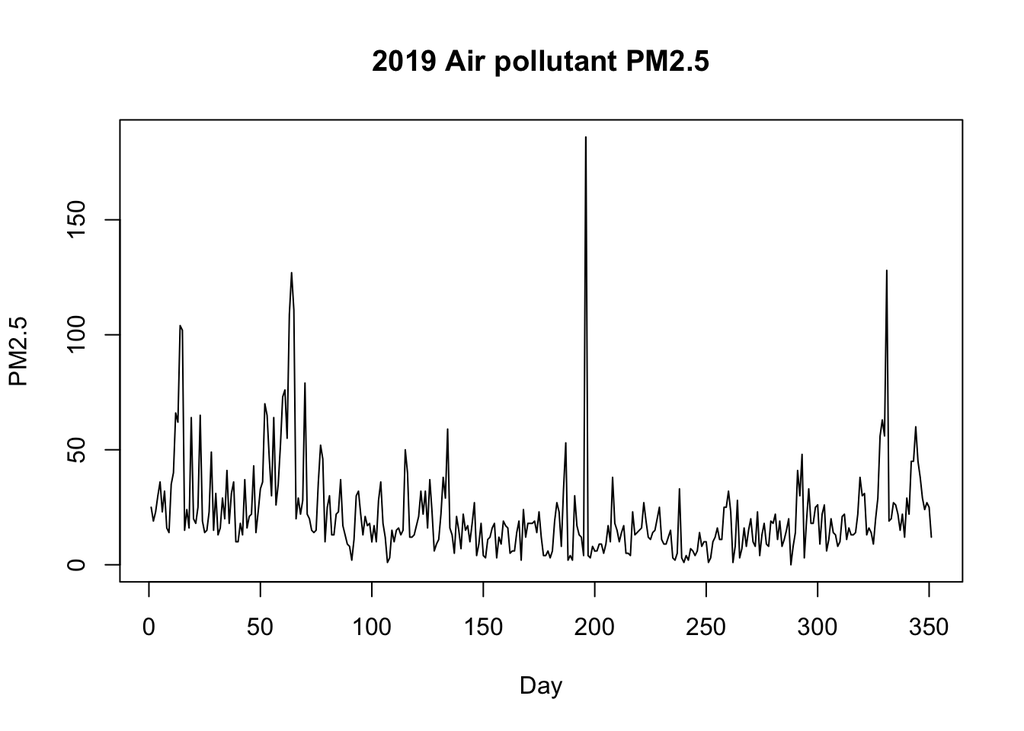

```r
data <- read.csv("/Users/apple/Desktop/data1year.csv",header=TRUE)
pollution = as.ts(data$PM2.5)
plot(pollution, main = "2019 Air pollutant PM2.5", xlab = "Day",ylab = "PM2.5")
```

Base on the plot of the air pollate PM2.5, we can find there are no obvious trend and seasonal effect in the plot, but we can find there are some cyclical effects and a large cyclical effects appears around 200.

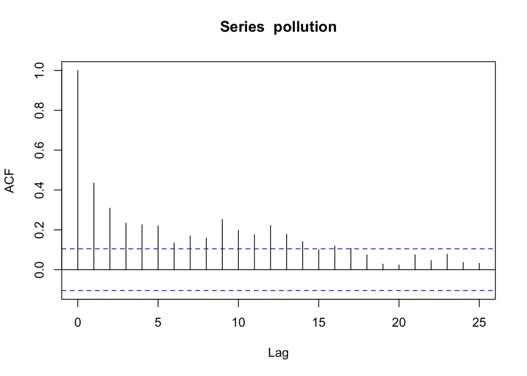

```r
acf(pollution)
```

Base on the acf plot of the air polluate PM2.5, we can find the acf value is decreasing(some of large value at lag 9 and lag 12), and the acf plot shows it is non-statinary time series, it is time dependent.